# Best practices in R

Dr. Danger

[figure not shown]

# Save your work!

Click the little blue disk save icon to save your work. This way if something goes wrong with your computer, you won’t lose hours of work!

# Knit early, knit often!!

By making small incremental changes and knitting often, if a bug i.e. an “error” creeps into your code, you’ll be able to isolate where it is easier! Note that knitting also performs a save automatically!

# Put white spaces between code chunks!

While the computer doesn’t care if your code is easy to read, humans do! Careful use of formatting tricks like using blank spaces between code chunks can go a long way to make your code easier to read. Be emphathetic to potential collaborators who might read this code! Including your [most important collaborator of all!!!](https://rmhogervorst.nl/cleancode/blog/2016/05/26/content/post/2016-05-26-your-most-valuable-collaborator-future-you/)

## For instance, do this:

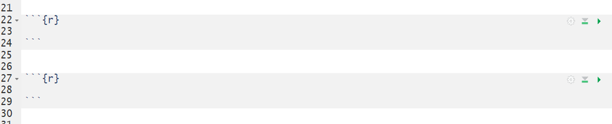

## Do not do this:

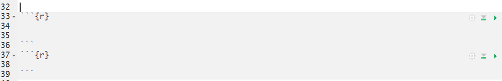

# Only a little bit of code per chunk!!

Don’t be afraid to break up your code into several chunks. For example, create one code chunk per rough task.

### Or this will be you looking for your errors in a haystack of code.

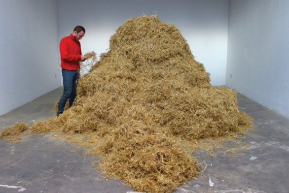

# Put files into folders

## in places you can find!

### Or this will be you looking for your files!

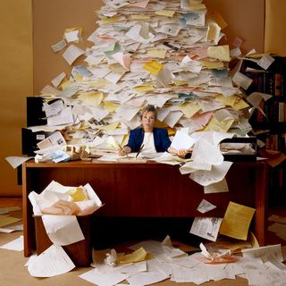